# Statistical Inference Course Project 1

Ben Weinert

March 12, 2016

# Project

In this project you will investigate the exponential distribution in R and compare it with the Central Limit Theorem. The exponential distribution can be simulated in R with rexp(n, lambda) where lambda ($\lambda$) is the rate parameter. The mean of exponential distribution is 1/lambda and the standard deviation is also 1/lambda. Set lambda = 0.2 for all of the simulations. You will investigate the distribution of averages of 40 exponential. Note that you will need to do a thousand simulations.

## Creating the Dataset

```r
#Set the seed
set.seed(123)

#Set lambda
lambda<-0.2

#Set number of Observations
obvs<-40

#Set number of simulations
sim<-1000

#simulate
simexp<-matrix(rexp(sim*obvs,rate=lambda),nrow=sim,ncol=obvs)

#create vector of means
mean_simexp<-apply(simexp,1,mean)
```

## Question 1

Show where the distribution is centered at and compare it to the theoretical center of the distribution.

```r
#Calculate analytical mean
anmean<-mean(mean_simexp)
anmean
```

```
## [1] 5.011911
```

```r
#Calculate theoretical mean
thmean<-1/lambda
thmean
```

```
## [1] 5
```

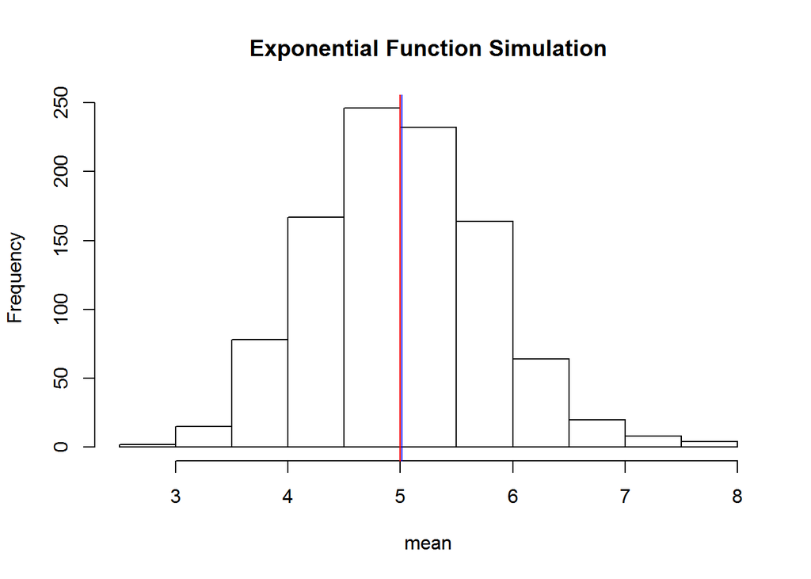

```r
#plot the means
hist(mean_simexp,xlab="mean",main="Exponential Function Simulation")
abline(v=anmean,col="blue")
abline(v=thmean,col="red")
```

## Question 2

Show how variable it is and compare it to the theoretical variance of the distribution.

```r
#Standard deviation of data
sd_data<-sd(mean_simexp)
sd_data
```

```
## [1] 0.7802751
```

```r
#Variance deviation of data
var_data<-sd_data^2
var_data
```

```
## [1] 0.6088292
```

```r
#Standard deviation of theory
sd_theory<-(1/lambda)/sqrt(obvs)
sd_theory
```

```
## [1] 0.7905694
```

```r
#Variance deviation of theory
var_th<-sd_theory^2
var_th
```

```
## [1] 0.625
```

The standard deviation of the data was 0.7802751, and the theoretical standard deviation was $\frac{1}{\lambda\sqrt{n}}$=0.7905694. The variance is the square of the standard deviation. For the data the variance is 0.6088292 and for the theory it is 0.625.

## Question 3

Show that the distribution is approximately normal.

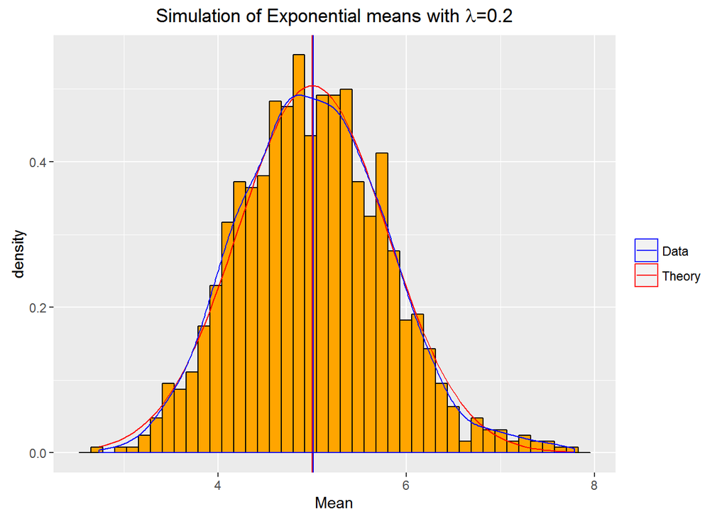

```r
#Plot the distribution, and show the mean/density of the data (blue)
#and the mean of and normal density of the theory(red)
library(ggplot2)
ggplot(data.frame(mean_simexp),aes(x=mean_simexp)) +
        geom_histogram(aes(y=..density..),col="black",fill="orange",bins=40) +
        geom_vline(xintercept=c(anmean,thmean),col=c("blue","red")) +
        stat_function(fun=dnorm, args=list(mean=thmean,sd=sd_theory),aes(color="Theory")) +
        geom_density(aes(color="Data")) +
        ggtitle(expression(paste("Simulation of Exponential means with ",lambda,"=0.2"))) +
        xlab("Mean") +
        scale_color_manual(name=" ",values=c("Theory"="red","Data"="blue"))
```

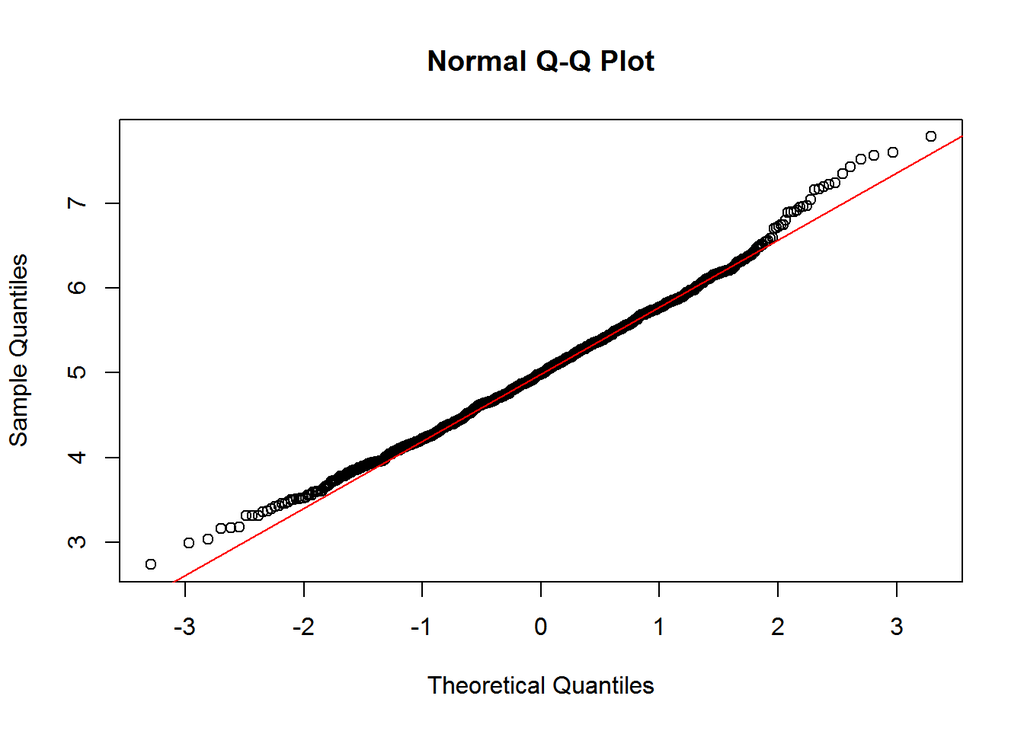

```r
#Compare the the quantiles of the distribution of averages of 40 exponentials
#to the normal distribution (red line)
qqnorm(mean_simexp)
qqline(mean_simexp,col="red")
```

The Normal Q-Q plot shows the quantiles (x-axis) for the value mean (y-axis) for a normal distribution. The red line is the theoretical quantiles for a normal distributions, and the circles are the data distribution. For most of the length of the distribution, the data is very close to the normal distribution.

Because of the large number of observations in each simulation, the distribution of averages of the exponential approaches the normal distribution due to the Central Limit Theorem (CLT).